# Demo 7 | The Scale and Aggregation Problems in MAUP

Peter Kedron

2026-10-20

# Introduction

The modifiable areal unit problem (MAUP) describes how a statistic can depend on the spatial units used to calculate it. Even when the underlying observations stay the same, combining them into different units can change the apparent relationship between variables. This demonstration adapts the Iowa county example discussed in the accompanying Openshaw MAUP material.

We begin with Iowa county data on the percentage of votes cast for the Republican presidential candidate in 1968 and the percentage of residents aged 60 or older in 1970. We calculate a county-level Pearson correlation, then recompute both percentages and their correlation after combining counties. The resulting correlation describes a relationship between areas; it does not tell us how individual residents voted.

Two choices about spatial units matter here:

1. **Aggregation problem:** Holding the number of resulting units fixed, we can combine the counties in different ways. The correlation can vary across those alternative arrangements.
2. **Scale problem:** We can change how many resulting units there are. The correlation may also change as we aggregate the counties into fewer or more units.

We examine both choices using two procedures. The **zoning algorithm** combines neighboring counties into contiguous zones. The **grouping algorithm** assigns counties to groups without a contiguity requirement. Part 1 holds the number of zones or groups at eight while the instructor demonstrates the algorithms. In Part 2, students vary the number of units and compare repeated results.

# Set Up

Load in the data. The voting data is from the 1968 presidential election, and the census data is from the 1970 census. The geojson contains the geometries for Iowa’s counties.

```r
vote1968 <- read.csv("data/1968vote.csv")
census1970 <- read.csv("data/1970census.csv")
iowa <- st_read("data/iowa_county.geojson")
```

Process the data to create the variables we need for the activity. We need to calculate the percentage of votes for the Republican candidate in 1968, and the percentage of the population that is 60 years or older in 1970. We also need to clean up the county names to make sure they match across datasets.

```r
vote1968 <- vote1968 %>%
  mutate(pct_rep = 100 * (repvote / totalvote))

census1970 <- census1970 %>%
  mutate(Geo_NAME = str_remove(Geo_NAME, " County")) %>%
  rename(pop65 = SE_T007_005, totalpop = SE_T007_001, pop6064 = X60_64, County = Geo_NAME) %>%
  dplyr:: select(County, pop65, pop6064, totalpop) %>%
  mutate(pop60 = pop6064 + pop65,
         pop60_pct = pop60 / totalpop * 100)

iowa <- iowa %>%
  rename(County = NAME) %>%
  st_transform(crs = 6464)
```

```r
clean_county <- function(x) {
  x %>%
    str_trim() %>%
    str_remove(" County$") %>%
    str_replace_all("['’]", "") %>%
    str_squish() %>%
    str_to_title()
}

census1970 <- census1970 %>%
  mutate(County = clean_county(County))

vote1968 <- vote1968 %>%
  mutate(County = clean_county(County))
```

After cleaning the county names, we can join the datasets together. We will use a left join to keep all the counties in the Iowa dataset, and add the census and voting data to it.

```r
iowa_data <- iowa %>%
  left_join(census1970, by = "County") %>%
  left_join(vote1968, by = "County") %>%
  dplyr::select(County, GEOID, COUNTYNS, pop60, totalpop, pop60_pct, totalvote, repvote, pct_rep, geometry)
```

Let’s take a look at the baseline correlation between the percentage of votes for the Republican candidate and the percentage of the population that is 60 years or older in Iowa counties. This will give us a reference point to compare with the correlations we get from the zoning and grouping algorithms.

```r
baseline_corr <- cor(iowa_data$pct_rep, iowa_data$pop60_pct, use = "complete.obs")
cat("Baseline correlation between % Republican vote and % population 60+ in Iowa counties:", round(baseline_corr, 3))
```

```
## Baseline correlation between % Republican vote and % population 60+ in Iowa counties: 0.22
```

# The Zoning and Grouping Algorithm

Below is the zoning algorithm used in Openshaw’s 1977 paper. This algorithm is a random accretion method that starts with randomly selected core zones and then randomly absorbs neighboring zones until the desired number of zones is reached. Please run the code chunk below.

```r
zone1_r <- function(nb, N, M, fixed_zones = integer(0)) {
  # nb: a neighbor list from spdep::poly2nb()
  # N: number of original zones
  # M: desired number of output zones

  stopifnot(M < N)

  # --- Initialize ---
  # Creates a vector of zeros.
  # A 0 means not yet assigned to any zone.
  ipart <- integer(N)

  n_fixed <- length(fixed_zones)
  if (n_fixed > 0) {
    for (i in seq_along(fixed_zones)) {
      ipart[fixed_zones[i]] <- i
    }
  }
  n_cores_needed <- M - n_fixed

  # --- Step 1: Randomly select M core zones ---
  available <- which(ipart == 0)
  core_indices <- sample(available, n_cores_needed)

  for (i in seq_along(core_indices)) {
    ipart[core_indices[i]] <- n_fixed + i
  }
  active_cores <- (n_fixed + 1):M

  # --- Step 2: Random accretion loop ---
  max_iter <- N * M * 10  # safety limit
  iter <- 0

  # stop until safety limit or no active cores with unallocated neighbors
  while (length(active_cores) > 0 && iter < max_iter) {
    iter <- iter + 1

    # pick a random active core
    core_label <- sample(active_cores, 1)

    # find all zones belonging to this core
    core_members <- which(ipart == core_label)

    # find unallocated neighbors of any core member
    unalloc_neighbors <- c()
    for (z in core_members) {
      neighbors <- nb[[z]]
      if (!(length(neighbors) == 1 && neighbors == 0)) {  # 0 means no neighbors in spdep
        unalloc <- neighbors[ipart[neighbors] == 0]
        unalloc_neighbors <- union(unalloc_neighbors, unalloc)
      }
    }

    if (length(unalloc_neighbors) == 0) {
      # this core can't grow, deactivate it
      active_cores <- setdiff(active_cores, core_label)
    } else {
      # randomly absorb one neighbor
      chosen <- ifelse(
        length(unalloc_neighbors) == 1,
        unalloc_neighbors,
        sample(unalloc_neighbors, 1)
      )
      ipart[chosen] <- core_label
    }
  }

  # --- Check for unallocated zones (islands) ---
  unallocated <- which(ipart == 0)
  ifault <- length(unallocated)

  if (ifault > 0) {
    warning(paste(ifault, "zones could not be allocated (contiguity islands)"))
    for (i in seq_along(unallocated)) {
      ipart[unallocated[i]] <- M + i
    }
  }
  list(
    ipart    = ipart,
    ifault   = ifault,
    n_zones  = length(unique(ipart))
  )
}
```

Besides the zoning algorithm, we also need a function to generate random groupings of the original zones. This is used in the aggregation problem to create zones that’s not necessarily contiguous. Please run the code chunk below.

```r
random_grouping <- function(N, M) {
  # guarantee each group appears at least once
  base <- sample(M)
  rest <- sample(M, N - M, replace = TRUE)
  sample(c(base, rest))
}
```

# Part 1 - The Aggregation Problem

In part one, we will explore the aggregation problem by using the zoning algorithm to create 8 different contiguous zones in Iowa. We will then calculate the percentage of votes for the Republican candidate and the percentage of the population that is 60 years or older in each zone, and see how they correlate with each other. Please run the code below.

```r
# neighbor list
nb <- poly2nb(iowa_data, queen = FALSE)

# number of original zones
N <- nrow(iowa_data)

# different target numbers of zones
M_agg <- 8
```

The code below first runs the zoning algorithm to create 8 different contiguous zones in Iowa. Then, based on the zones generated by the zoning algorithm, we now re-calculate the percentage of votes for the Republican candidate and the percentage of the population that is 60 years or older in each zone, and see how they correlate with each other.

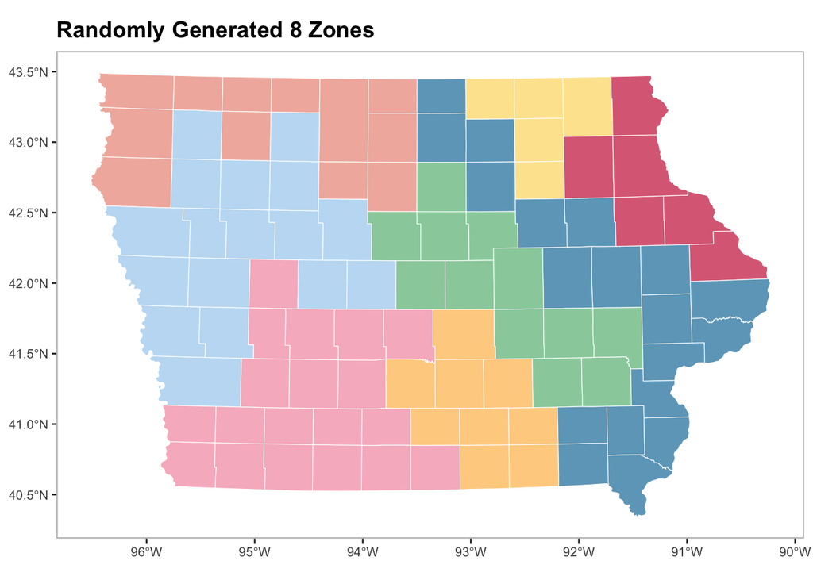

```r
zoning_results <- zone1_r(nb, N, M_agg)

iowa %>%
  mutate(zone = factor(zoning_results$ipart)) %>%
  ggplot() +
    geom_sf(aes(fill = zone), color = "white", linewidth = 0.2) +
    theme +
    scale_fill_manual(values = palette) +
    labs(title = paste("Randomly Generated", M_agg, "Zones"))
```

```r
zone_summary <- iowa_data %>%
  mutate(zone = factor(zoning_results$ipart)) %>%
  st_drop_geometry() %>%
  group_by(zone) %>%
  summarise(
      total_pop   = sum(totalpop, na.rm = TRUE),
      total_vote  = sum(totalvote, na.rm = TRUE),
      rep_count   = sum(repvote, na.rm = TRUE),
      pop60_count = sum(pop60, na.rm = TRUE),
      .groups = "drop") %>%
    mutate(rep_pct   = 100 * rep_count / total_vote,
           pop60_pct = 100 * pop60_count / total_pop)
scale_corr <- cor(zone_summary$rep_pct, zone_summary$pop60_pct, use = "complete.obs")
cat("Correlation between % Republican vote and % population 60+ in 8 zones:", round(scale_corr, 3))
```

```
## Correlation between % Republican vote and % population 60+ in 8 zones: 0.274
```

We will repeat the exact the same process with the grouping algorithm. The code below first runs the random grouping function to create 8 different groups in Iowa. Then, based on the groups generated by the random grouping function, we now re-calculate the percentage of votes for the Republican candidate and the percentage of the population that is 60 years or older in each group, and see how they correlate with each other.

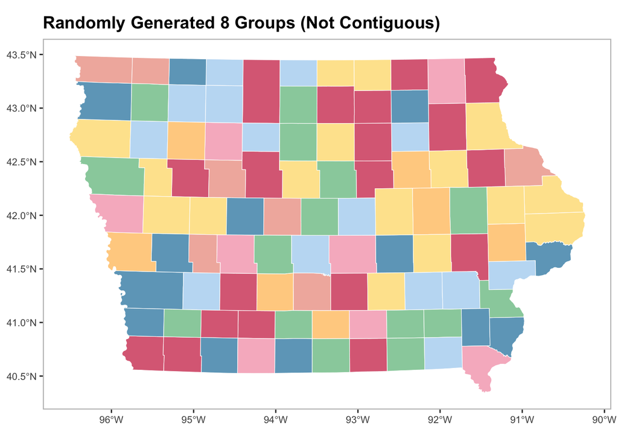

```r
grouping_results <- random_grouping(N, M_agg)

iowa %>%
  mutate(group = factor(grouping_results)) %>%
  ggplot() +
    geom_sf(aes(fill = group), color = "white", linewidth = 0.2) +
    theme +
    scale_fill_manual(values = palette) +
    labs(title = paste("Randomly Generated", M_agg, "Groups (Not Contiguous)"))
```

```r
group_summary <- iowa_data %>%
  mutate(group = factor(grouping_results)) %>%
  st_drop_geometry() %>%
  group_by(group) %>%
  summarise(
      total_pop   = sum(totalpop, na.rm = TRUE),
      total_vote  = sum(totalvote, na.rm = TRUE),
      rep_count   = sum(repvote, na.rm = TRUE),
      pop60_count = sum(pop60, na.rm = TRUE),
      .groups = "drop") %>%
    mutate(rep_pct   = 100 * rep_count / total_vote,
           pop60_pct = 100 * pop60_count / total_pop)
group_corr <- cor(group_summary$rep_pct, group_summary$pop60_pct, use =
 "complete.obs")
cat("Correlation between % Republican vote and % population 60+ in 8 groups:", round(group_corr, 3))
```

```
## Correlation between % Republican vote and % population 60+ in 8 groups: 0.453
```

# Part 2 - The Scale Problem

In part two, we will explore the scale problem by using both the zoning and grouping algorithm to create different zones in Iowa, and see how the correlation change. This time, you are encouraged to experiment with different numbers of zones/groups (M) and run the algorithms multiple times as much as you want.

**Instructions for in-class activity**

1. Run the Section 2 set up chunks in your own R session. The experiment needs `iowa_data`, `nb`, `N`, `zone1_r()`, and `random_grouping()`.
2. In the next chunk, replace `#####` after `M_scl <-` with **one whole number from 6 through 80**, such as `M_scl <- 12`. Keep the rest of the code unchanged.
3. Run the entire chunk. It creates one zoning arrangement and one grouping arrangement with your chosen number of units. It then prints a correlation for each.
4. Record `M_scl`, the zoning correlation, and the grouping correlation. Rerun the chunk at least once **without changing** `M_scl` to see variation across arrangements at a fixed number of units.
5. Change `M_scl` to other values and run the chunk again. Record each result. Compare correlations at the same number of units, at different numbers of units, and between zoning and grouping. Keep a record before the next run replaces the console output.
6. At the end, report the **highest and lowest** correlations your group observed, along with the method and number of units that produced each. These extreme values are examples from your runs, not the full range of possible correlations.

```r
M_scl <- 8 ##### you can change this to any number between 6 and 80.

zoning_results_agg <- zone1_r(nb, N, M_scl)
grouping_results_agg <- random_grouping(N, M_scl)

agg_zones_summary <- iowa_data %>%
  mutate(zone = factor(zoning_results_agg$ipart)) %>%
  st_drop_geometry() %>%
  group_by(zone) %>%
  summarise(
      total_pop   = sum(totalpop, na.rm = TRUE),
      total_vote  = sum(totalvote, na.rm = TRUE),
      rep_count   = sum(repvote, na.rm = TRUE),
      pop60_count = sum(pop60, na.rm = TRUE),
      .groups = "drop") %>%
    mutate(rep_pct   = 100 * rep_count / total_vote,
           pop60_pct = 100 * pop60_count / total_pop)
agg_zones_corr <- cor(agg_zones_summary$rep_pct, agg_zones_summary$pop60_pct, use = "complete.obs")
agg_groups_summary <- iowa_data %>%
  mutate(group = factor(grouping_results_agg)) %>%
  st_drop_geometry() %>%
  group_by(group) %>%
  summarise(
      total_pop   = sum(totalpop, na.rm = TRUE),
      total_vote  = sum(totalvote, na.rm = TRUE),
      rep_count   = sum(repvote, na.rm = TRUE),
      pop60_count = sum(pop60, na.rm = TRUE),
      .groups = "drop") %>%
    mutate(rep_pct   = 100 * rep_count / total_vote,
           pop60_pct = 100 * pop60_count / total_pop)
agg_groups_corr <- cor(agg_groups_summary$rep_pct, agg_groups_summary$pop60_pct, use = "complete.obs")
cat("Correlation between % Republican vote and % population 60+ in", M_scl, "zones:", round(agg_zones_corr, 3),
    "\nCorrelation between % Republican vote and % population 60+ in", M_scl, "groups:", round(agg_groups_corr, 3))
```

```
## Correlation between % Republican vote and % population 60+ in 8 zones: 0.88
## Correlation between % Republican vote and % population 60+ in 8 groups: 0.515
```